# Boylad

## Life Rethinking

Dec 31, 2020

# Q城往事·2020

> 成长，从不是年龄在时间轴线上的缓慢堆积，也不是肉体在三维空间里的辗转往复，它甚至不关乎精神层面上的任何东西。成长是一部大书，它从不连续，只能跳跃，每一次跳跃，每一次成长，必以生离死别来句读。——《致W》

命运给了我一颗糖，或许是最好的那颗，我却没能珍惜。人总是能从经历中成长和进步。随着COVID-19的蔓延，2020年我的生活中发生了很多事情，不过这一切已经过去了。

Aug 31, 2020

# August, 2020

[figure not shown]

Jul 31, 2020

# July, 2020

[interactive chart not shown]

七月末，Q城夏雨连绵，温度与湿度达到了一种令人惬意的均衡，校园里充满了秋日的柔和。这是我回到Q城的第50天。万物静默如谜。

两年来，我没有在Q城某片海滩的石块下面找到阿里阿德涅的线头，这意味着某些事情算是告一段落了。事实上，我早已看透了这一切的不幸，正如我早已看透这不幸的一切。值得欣慰的一点是，我依旧能以终为始地不降其志，不辱其身。这些年里，我曾一厢情愿地沉溺于某种情感，现在终于得到了解脱。

分别总是在七月。Cool，pope和W今年研究生毕业，各自都找到了合意的工作，开始使生活充满意义。某个日落的黄昏，超哥（下图，右）请了一顿烧烤，祝贺朋友（下图，左）毕业。一曲毛不易的《入海》送给他们，愿他们在尘世获得幸福。

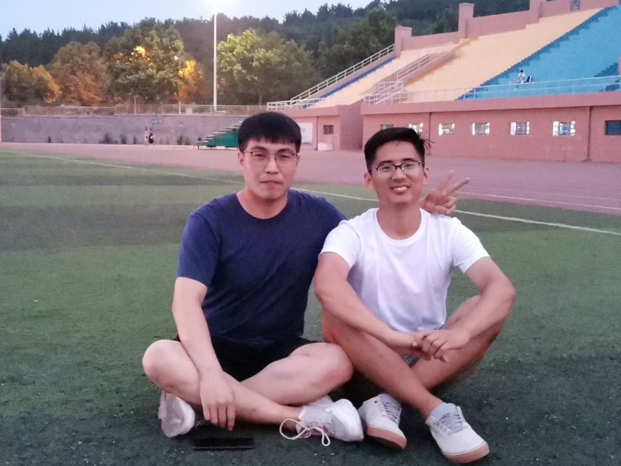

笔友Fata 小叶从[第三极](https://movie.douban.com/subject/26258064/)拉萨寄来了“扎西蜜语”，金丝皇菊，转经轮以及一封信。于是在短暂的2020我们可以继续分享知识以及对于生活的体验。

[figure not shown]

> **“转经轮”**，亦称“玛尼解脱轮”，属佛教法器。其中装藏经文或咒语，通过顺时针转动即等同念诵之功。

最近喝了很多来自雪山高原的蜂蜜金丝皇菊茶和冲浪美式咖啡，也渐渐喜欢上了sparkling water。

[figure not shown]

两个晚上读完了《你当像鸟飞往你的山》，感慨万千。

> Flee as a bird to your mountain. ——*Bible·Psalms*

这句话出自《[圣经·诗篇](https://biblehub.com/psalms/11-1.html)》，也是《Educated》这本书的中文译名，意思有两种，一个是“逃离”，另一个是“找到新的信仰”。作者[塔拉](https://en.wikipedia.org/wiki/Tara_Westover)出生在巴克峰一个信仰[摩门教](https://en.wikipedia.org/wiki/Mormonism)的家庭中，童年由垃圾场的废铜烂铁铸成，因为家庭信仰，17岁之前没上过学，生病也不去看医生。后来受哥哥泰勒的影响，自学考上大学，逃离巴克峰，获得剑桥大学博士学位，最终找到了全新的自我。别人也许会称呼这个自我为：转变、蜕变、虚伪、背叛。而塔拉称之为教育！

> Spent two nights, reading this book, I was shocked. [pic.twitter.com/MkkPaqe6hz](https://t.co/MkkPaqe6hz)

> — Boylad (@Guankui_Liu) [July 30, 2020](https://twitter.com/Guankui_Liu/status/1288875017804144646?ref_src=twsrc%5Etfw)

塔拉在接受《福布斯杂志》访谈时说：

> 教育意味着获得不同的视角，理解不同的人、经历和历史。接受教育，但不要让你的教育僵化成傲慢。教育应该是你思想的拓展，同理心的深化，视野的开阔。它不应该使你的偏见变得更顽固。如果人们受过教育，他们应该变得不那么确定，而不是更确定。他们应该多听，少说。他们应该对差异满怀激情，热爱那些不同于他们的想法。